# Testeo_modelo_ predictivo.ver 2

> Este archivo contiene la segunda version del modelo de evaluacion del rol de los datos ausentes en el modelo predictivo a partir de distintas combinaciones sistemáticas de datos faltantes (que pasaria con el desempeño del modelo si estas variables no estuvieran disponibles -escenarios contrafactuales-). Este analisis sirve para estimar la confiabilidad del modelo bajo distintos escenarios y muestra ademas el rol significativo de algunas variables predictivas por sobre otras, tal como sugiere el modelo base

```r
#paquetes
library(tidymodels)
library(tidyverse)
```

```r
library(recipes)
library(parsnip)
library(yardstick)
library(purrr)
library(tibble)
library(ggplot2)
library(dplyr)
```

```r
#Abrir modelos predictores
xgb_fit_CS      <- readRDS("xgb_fit_CS.rds")
svm_rad_fit_CI  <- readRDS("svm_rad_fit_CI.rds")
```

```r
#check xgb
xgb_fit_CS
```

```
## ══ Workflow [trained] ══════════════════════════════════════════════════════════
## Preprocessor: Recipe
## Model: boost_tree()
##
## ── Preprocessor ────────────────────────────────────────────────────────────────
## 2 Recipe Steps
##
## • step_impute_knn()
## • step_normalize()
##
## ── Model ───────────────────────────────────────────────────────────────────────
## ##### xgb.Booster
## call:
##   xgboost::xgb.train(params = list(eta = 0.00146779926762207, max_depth = 4L,
##     gamma = 0.0215443469003188, colsample_bytree = 1, colsample_bynode = 0.5,
##     min_child_weight = 3L, subsample = 1, nthread = 1, objective = "binary:logistic"),
##     data = x$data, nrounds = 800, evals = x$watchlist, verbose = 0)
## # of features: 4
## # of rounds:  800
## callbacks:
##    evaluation_log
## evaluation_log:
##     iter training_logloss
##        1        0.6920323
##        2        0.6912087
## ---
##      799        0.3705706
##      800        0.3703958
```

```r
#check svm radial
svm_rad_fit_CI
```

```
## ══ Workflow [trained] ══════════════════════════════════════════════════════════
## Preprocessor: Recipe
## Model: svm_rbf()
##
## ── Preprocessor ────────────────────────────────────────────────────────────────
## 2 Recipe Steps
##
## • step_impute_knn()
## • step_normalize()
##
## ── Model ───────────────────────────────────────────────────────────────────────
## Support Vector Machine object of class "ksvm"
##
## SV type: C-svc  (classification)
##  parameter : cost C = 0.435275281648062
##
## Gaussian Radial Basis kernel function.
##  Hyperparameter : sigma =  0.1
##
## Number of Support Vectors : 85
##
## Objective Function Value : -31.4959
## Training error : 0.153846
## Probability model included.
```

```r
#modelo ajustado para canino superior CS

xgb_fit = readRDS("xgb_fit_CS.rds")

xgb_fit
```

```
## ══ Workflow [trained] ══════════════════════════════════════════════════════════
## Preprocessor: Recipe
## Model: boost_tree()
##
## ── Preprocessor ────────────────────────────────────────────────────────────────
## 2 Recipe Steps
##
## • step_impute_knn()
## • step_normalize()
##
## ── Model ───────────────────────────────────────────────────────────────────────
## ##### xgb.Booster
## call:
##   xgboost::xgb.train(params = list(eta = 0.00146779926762207, max_depth = 4L,
##     gamma = 0.0215443469003188, colsample_bytree = 1, colsample_bynode = 0.5,
##     min_child_weight = 3L, subsample = 1, nthread = 1, objective = "binary:logistic"),
##     data = x$data, nrounds = 800, evals = x$watchlist, verbose = 0)
## # of features: 4
## # of rounds:  800
## callbacks:
##    evaluation_log
## evaluation_log:
##     iter training_logloss
##        1        0.6920323
##        2        0.6912087
## ---
##      799        0.3705706
##      800        0.3703958
```

```r
#Conjuntos originales de testeo
cs_test=read.table("Conjunto_testeo_CS.txt",T)
ci_test=read.table("Conjunto_testeo_CI.txt",T)
```

```r
#Check modelo CS
cs_test$Sexo=as.factor(cs_test$Sexo)

pred_cs <- predict(xgb_fit_CS, cs_test) %>%
  bind_cols(cs_test["Sexo"])

bal_accuracy(pred_cs, truth = Sexo, estimate = .pred_class)
```

| .metric | .estimator | .estimate |
| --- | --- | --- |
| bal_accuracy | binary | 0.7857143 |

```r
ci_test$Sexo=as.factor(ci_test$Sexo)

pred_ci <- predict(svm_rad_fit_CI, ci_test) %>%
  bind_cols(ci_test["Sexo"])

bal_accuracy(pred_ci, truth = Sexo, estimate = .pred_class)
```

| .metric | .estimator | .estimate |
| --- | --- | --- |
| bal_accuracy | binary | 0.8095238 |

```r
#Filtrar solo datos presentes para la simulacion y generacion del baseline

cs_test_complete <- cs_test %>%
  dplyr::filter(
    !is.na(MD),
    !is.na(BL),
    !is.na(MDCu),
    !is.na(BLCu)
  )

ci_test_complete <- ci_test %>%
  dplyr::filter(
    !is.na(MD),
    !is.na(BL),
    !is.na(MDCu),
    !is.na(BLCu))
```

```r
#check
summary(cs_test_complete)
```

```
##       Ind         Tipo_Diente              MD              BL
##  Min.   :  2.00   Length:42          Min.   :6.280   Min.   :6.150
##  1st Qu.: 54.25   Class :character   1st Qu.:7.120   1st Qu.:7.580
##  Median : 90.00   Mode  :character   Median :7.340   Median :8.110
##  Mean   : 92.36                      Mean   :7.402   Mean   :8.015
##  3rd Qu.:121.50                      3rd Qu.:7.662   3rd Qu.:8.432
##  Max.   :199.00                      Max.   :8.320   Max.   :9.490
##       MDCu            BLCu       Sexo        Edad
##  Min.   :4.550   Min.   :6.620   F:21   Min.   :12.00
##  1st Qu.:5.202   1st Qu.:7.180   M:21   1st Qu.:18.00
##  Median :5.500   Median :7.675          Median :24.00
##  Mean   :5.516   Mean   :7.624          Mean   :26.26
##  3rd Qu.:5.780   3rd Qu.:8.057          3rd Qu.:30.75
##  Max.   :6.790   Max.   :8.790          Max.   :57.00
```

```r
summary(ci_test_complete)
```

```
##       Ind         Tipo_Diente              MD              BL
##  Min.   :  2.00   Length:41          Min.   :5.650   Min.   :6.660
##  1st Qu.: 54.00   Class :character   1st Qu.:6.200   1st Qu.:7.090
##  Median : 92.00   Mode  :character   Median :6.520   Median :7.550
##  Mean   : 92.85                      Mean   :6.559   Mean   :7.521
##  3rd Qu.:122.00                      3rd Qu.:6.990   3rd Qu.:7.860
##  Max.   :199.00                      Max.   :7.390   Max.   :8.750
##       MDCu            BLCu      Sexo        Edad
##  Min.   :4.450   Min.   :6.50   F:20   Min.   :12.00
##  1st Qu.:4.900   1st Qu.:6.92   M:21   1st Qu.:18.00
##  Median :5.310   Median :7.28          Median :24.00
##  Mean   :5.247   Mean   :7.36          Mean   :25.76
##  3rd Qu.:5.530   3rd Qu.:7.72          3rd Qu.:30.00
##  Max.   :5.950   Max.   :8.68          Max.   :57.00
```

> parece OK..sin NA´s

```r
#Funcion generadora de escenarios

make_na_scenarios <- function(vars) {

  combos_1 <- combn(vars, 1, simplify = FALSE)
  combos_2 <- combn(vars, 2, simplify = FALSE)
  combos_3 <- combn(vars, 3, simplify = FALSE)

  all_combos <- c(combos_1, combos_2, combos_3)

  names(all_combos) <- sapply(all_combos, paste, collapse = "_")

  return(all_combos)
}
```

```r
##test minimo un escenario.. CI

test_mod <- ci_test_complete
test_mod$MDCu <- NA

pred_test <- predict(svm_rad_fit_CI, test_mod) %>%
  bind_cols(test_mod["Sexo"])

bal_accuracy(pred_test, truth = Sexo, estimate = .pred_class)
```

| .metric | .estimator | .estimate |
| --- | --- | --- |
| bal_accuracy | binary | 0.7809524 |

> Parece que da OK

```r
#Funcion robustez simplificada
evaluar_robustez <- function(modelo_fit, test_data, nombre_modelo) {

  vars <- c("MD","BL","MDCu","BLCu")

  # baseline
  baseline_pred <- predict(modelo_fit, test_data) %>%
    dplyr::bind_cols(test_data["Sexo"])

  baseline_BA <- yardstick::bal_accuracy(
    baseline_pred,
    truth = Sexo,
    estimate = .pred_class
  )$.estimate

  scenarios <- make_na_scenarios(vars)

  resultados <- purrr::imap_dfr(scenarios, function(miss_vars, scenario_name){

    test_mod <- test_data
    test_mod[, miss_vars] <- NA

    pred <- predict(modelo_fit, test_mod) %>%
      dplyr::bind_cols(test_mod["Sexo"])

    BA <- yardstick::bal_accuracy(
      pred,
      truth = Sexo,
      estimate = .pred_class
    )$.estimate

    tibble::tibble(
      modelo = nombre_modelo,
      escenario = scenario_name,
      n_na = length(miss_vars),
      BA = BA,
      dBA = BA - baseline_BA
    )
  })

  resultados$baseline_BA <- baseline_BA

  return(resultados)
}
```

```r
##Prueba para CI

robustez_CI <- evaluar_robustez(
  modelo_fit = svm_rad_fit_CI,
  test_data = ci_test_complete,
  nombre_modelo = "CI_SVM"
)
#check
robustez_CI
```

| modelo | escenario | n_na | BA | dBA | baseline_BA |
| --- | --- | --- | --- | --- | --- |
| CI_SVM | MD | 1 | 0.8047619 | -0.023809524 | 0.8285714 |
| CI_SVM | BL | 1 | 0.8535714 | 0.025000000 | 0.8285714 |
| CI_SVM | MDCu | 1 | 0.7809524 | -0.047619048 | 0.8285714 |
| CI_SVM | BLCu | 1 | 0.7797619 | -0.048809524 | 0.8285714 |
| CI_SVM | MD_BL | 2 | 0.8297619 | 0.001190476 | 0.8285714 |
| CI_SVM | MD_MDCu | 2 | 0.6833333 | -0.145238095 | 0.8285714 |
| CI_SVM | MD_BLCu | 2 | 0.7797619 | -0.048809524 | 0.8285714 |
| CI_SVM | BL_MDCu | 2 | 0.8047619 | -0.023809524 | 0.8285714 |
| CI_SVM | BL_BLCu | 2 | 0.8321429 | 0.003571429 | 0.8285714 |
| CI_SVM | MDCu_BLCu | 2 | 0.7559524 | -0.072619048 | 0.8285714 |

[output cut: 4 more lines]

```r
#Baseline datos completos CS

pred_cs_complete <- predict(xgb_fit_CS, cs_test_complete) %>%
  dplyr::bind_cols(cs_test_complete["Sexo"])

baseline_CS <- yardstick::bal_accuracy(
  pred_cs_complete,
  truth = Sexo,
  estimate = .pred_class
)

baseline_CS
```

| .metric | .estimator | .estimate |
| --- | --- | --- |
| bal_accuracy | binary | 0.7857143 |

> parece OK

```r
#Robustez bajo distintos NA en CS
robustez_CS <- evaluar_robustez(
  modelo_fit = xgb_fit_CS,
  test_data = cs_test_complete,
  nombre_modelo = "CS_XGB"
)
```

```r
#check
summary(robustez_CS$BA)
```

```
##    Min. 1st Qu.  Median    Mean 3rd Qu.    Max.
##  0.6190  0.6726  0.7024  0.7075  0.7321  0.7857
```

```r
range(robustez_CS$dBA)
```

```
## [1] -0.1666667  0.0000000
```

```r
#Resultados ordenados
robustez_CS %>%
  arrange(dBA)
```

| modelo | escenario | n_na | BA | dBA | baseline_BA |
| --- | --- | --- | --- | --- | --- |
| CS_XGB | BL_BLCu | 2 | 0.6190476 | -0.16666667 | 0.7857143 |
| CS_XGB | MD_BL_BLCu | 3 | 0.6428571 | -0.14285714 | 0.7857143 |
| CS_XGB | MD_MDCu_BLCu | 3 | 0.6666667 | -0.11904762 | 0.7857143 |
| CS_XGB | MDCu | 1 | 0.6666667 | -0.11904762 | 0.7857143 |
| CS_XGB | MD_MDCu | 2 | 0.6904762 | -0.09523810 | 0.7857143 |
| CS_XGB | MD_BLCu | 2 | 0.6904762 | -0.09523810 | 0.7857143 |
| CS_XGB | BL_MDCu_BLCu | 3 | 0.6904762 | -0.09523810 | 0.7857143 |
| CS_XGB | BLCu | 1 | 0.7142857 | -0.07142857 | 0.7857143 |
| CS_XGB | BL_MDCu | 2 | 0.7142857 | -0.07142857 | 0.7857143 |
| CS_XGB | MDCu_BLCu | 2 | 0.7142857 | -0.07142857 | 0.7857143 |

[output cut: 4 more lines]

```r
#reordenar y agregar degradacion respecto al linea de base
robustez_CS_tabla <- robustez_CS %>%
  dplyr::select(
    modelo,
    escenario,
    n_na,
    BA,
    dBA
  ) %>%
  dplyr::arrange(dBA)

robustez_CS_tabla
```

| modelo | escenario | n_na | BA | dBA |
| --- | --- | --- | --- | --- |
| CS_XGB | BL_BLCu | 2 | 0.6190476 | -0.16666667 |
| CS_XGB | MD_BL_BLCu | 3 | 0.6428571 | -0.14285714 |
| CS_XGB | MD_MDCu_BLCu | 3 | 0.6666667 | -0.11904762 |
| CS_XGB | MDCu | 1 | 0.6666667 | -0.11904762 |
| CS_XGB | MD_MDCu | 2 | 0.6904762 | -0.09523810 |
| CS_XGB | MD_BLCu | 2 | 0.6904762 | -0.09523810 |
| CS_XGB | BL_MDCu_BLCu | 3 | 0.6904762 | -0.09523810 |
| CS_XGB | BLCu | 1 | 0.7142857 | -0.07142857 |
| CS_XGB | BL_MDCu | 2 | 0.7142857 | -0.07142857 |
| CS_XGB | MDCu_BLCu | 2 | 0.7142857 | -0.07142857 |

[output cut: 4 more lines]

```r
#redondeado
robustez_CS_tabla <- robustez_CS_tabla %>%
  dplyr::mutate(
    BA = round(BA, 3),
    dBA = round(dBA, 3)
  )

robustez_CS_tabla
```

| modelo | escenario | n_na | BA | dBA |
| --- | --- | --- | --- | --- |
| CS_XGB | BL_BLCu | 2 | 0.619 | -0.167 |
| CS_XGB | MD_BL_BLCu | 3 | 0.643 | -0.143 |
| CS_XGB | MD_MDCu_BLCu | 3 | 0.667 | -0.119 |
| CS_XGB | MDCu | 1 | 0.667 | -0.119 |
| CS_XGB | MD_MDCu | 2 | 0.690 | -0.095 |
| CS_XGB | MD_BLCu | 2 | 0.690 | -0.095 |
| CS_XGB | BL_MDCu_BLCu | 3 | 0.690 | -0.095 |
| CS_XGB | BLCu | 1 | 0.714 | -0.071 |
| CS_XGB | BL_MDCu | 2 | 0.714 | -0.071 |
| CS_XGB | MDCu_BLCu | 2 | 0.714 | -0.071 |

[output cut: 4 more lines]

```r
#peores escenario

robustez_CS_tabla %>%
  group_by(n_na) %>%
  summarise(
    mean_dBA = mean(dBA),
    worst_dBA = min(dBA)
  )
```

| n_na | mean_dBA | worst_dBA |
| --- | --- | --- |
| 1 | -0.04750000 | -0.119 |
| 2 | -0.08316667 | -0.167 |
| 3 | -0.10125000 | -0.143 |

> El análisis de robustez mostró que la degradación promedio del desempeño predictivo aumenta progresivamente con el número de variables faltantes. En el modelo del canino superior (XGBoost), la pérdida de una sola variable produjo una disminución media de la Balanced Accuracy del 4,8% respecto del baseline, mientras que la ausencia de dos variables incrementó la degradación promedio al 8,3%, y la falta de tres variables alcanzó una reducción media del 10,1%. Este patrón indica un efecto acumulativo de la incompletitud, aunque no estrictamente lineal, ya que la mayor caída puntual se observó en un escenario específico con dos variables ausentes (−16,7%). En conjunto, estos resultados sugieren que el modelo mantiene una estabilidad razonable ante pérdidas parciales de información, pero muestra una sensibilidad marcada cuando se afectan simultáneamente dimensiones clave, particularmente aquellas asociadas a las medidas cervicales.

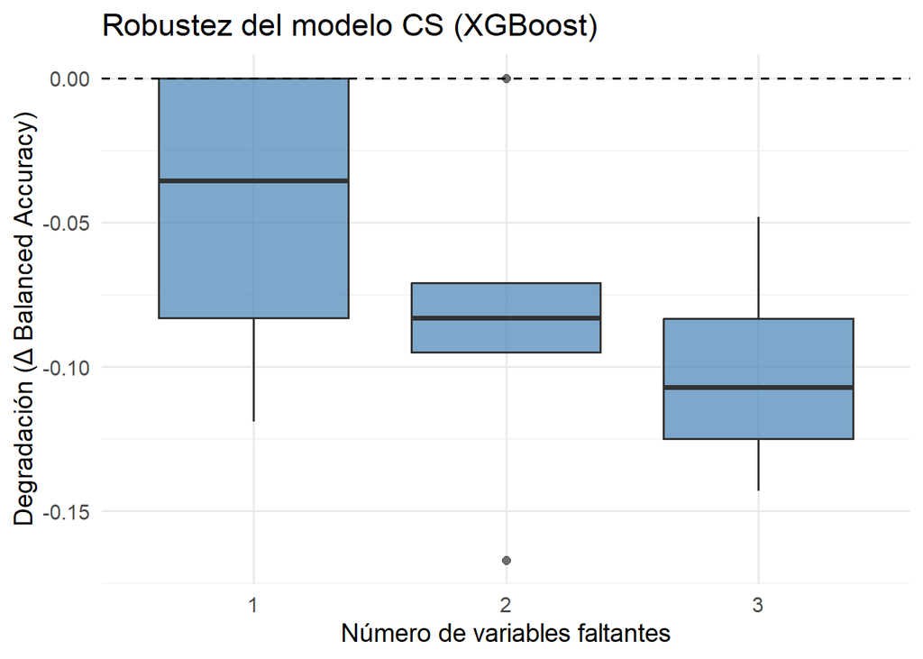

```r
#grafico en funcion variables faltantes CS
ggplot(robustez_CS_tabla,
       aes(x = factor(n_na),
           y = dBA)) +
  geom_boxplot(fill = "steelblue", alpha = 0.7) +
  geom_hline(yintercept = 0, linetype = "dashed") +
  theme_minimal(base_size = 14) +
  labs(
    x = "Número de variables faltantes",
    y = "Degradación (Δ Balanced Accuracy)",
    title = "Robustez del modelo CS (XGBoost)"
  )
```

```r
##Reglas de confianza
rules_confianza_CS <- robustez_CS_tabla %>%
  dplyr::mutate(
    nivel_confianza = dplyr::case_when(
      BA >= 0.75 ~ "Alta",
      BA >= 0.70 ~ "Moderada",
      TRUE       ~ "Baja"
    )
  ) %>%
  dplyr::arrange(n_na, BA)

rules_confianza_CS
```

| modelo | escenario | n_na | BA | dBA | nivel_confianza |
| --- | --- | --- | --- | --- | --- |
| CS_XGB | MDCu | 1 | 0.667 | -0.119 | Baja |
| CS_XGB | BLCu | 1 | 0.714 | -0.071 | Moderada |
| CS_XGB | MD | 1 | 0.786 | 0.000 | Alta |
| CS_XGB | BL | 1 | 0.786 | 0.000 | Alta |
| CS_XGB | BL_BLCu | 2 | 0.619 | -0.167 | Baja |
| CS_XGB | MD_MDCu | 2 | 0.690 | -0.095 | Baja |
| CS_XGB | MD_BLCu | 2 | 0.690 | -0.095 | Baja |
| CS_XGB | BL_MDCu | 2 | 0.714 | -0.071 | Moderada |
| CS_XGB | MDCu_BLCu | 2 | 0.714 | -0.071 | Moderada |
| CS_XGB | MD_BL | 2 | 0.786 | 0.000 | Alta |

[output cut: 4 more lines]

```r
#x numero de NA
rules_confianza_CS %>%
  group_by(n_na, nivel_confianza) %>%
  summarise(n = n(), .groups = "drop")
```

| n_na | nivel_confianza | n |
| --- | --- | --- |
| 1 | Alta | 2 |
| 1 | Baja | 1 |
| 1 | Moderada | 1 |
| 2 | Alta | 1 |
| 2 | Baja | 3 |
| 2 | Moderada | 2 |
| 3 | Baja | 3 |
| 3 | Moderada | 1 |

```r
############Segunda parte del codico CI###############
#####Extraccion baseline CI

pred_ci_complete <- predict(svm_rad_fit_CI, ci_test_complete) %>%
  dplyr::bind_cols(ci_test_complete["Sexo"])

baseline_CI <- yardstick::bal_accuracy(
  pred_ci_complete,
  truth = Sexo,
  estimate = .pred_class
)

baseline_CI
```

| .metric | .estimator | .estimate |
| --- | --- | --- |
| bal_accuracy | binary | 0.8285714 |

```r
#Robustez CI
robustez_CI <- evaluar_robustez(
  modelo_fit = svm_rad_fit_CI,
  test_data = ci_test_complete,
  nombre_modelo = "CI_SVM"
)

#check
robustez_CI
```

| modelo | escenario | n_na | BA | dBA | baseline_BA |
| --- | --- | --- | --- | --- | --- |
| CI_SVM | MD | 1 | 0.8047619 | -0.023809524 | 0.8285714 |
| CI_SVM | BL | 1 | 0.8535714 | 0.025000000 | 0.8285714 |
| CI_SVM | MDCu | 1 | 0.7809524 | -0.047619048 | 0.8285714 |
| CI_SVM | BLCu | 1 | 0.7797619 | -0.048809524 | 0.8285714 |
| CI_SVM | MD_BL | 2 | 0.8297619 | 0.001190476 | 0.8285714 |
| CI_SVM | MD_MDCu | 2 | 0.6833333 | -0.145238095 | 0.8285714 |
| CI_SVM | MD_BLCu | 2 | 0.7797619 | -0.048809524 | 0.8285714 |
| CI_SVM | BL_MDCu | 2 | 0.8047619 | -0.023809524 | 0.8285714 |
| CI_SVM | BL_BLCu | 2 | 0.8321429 | 0.003571429 | 0.8285714 |
| CI_SVM | MDCu_BLCu | 2 | 0.7559524 | -0.072619048 | 0.8285714 |

[output cut: 4 more lines]

```r
#Tabla con degradacion de BA
robustez_CI_tabla <- robustez_CI %>%
  dplyr::select(
    modelo,
    escenario,
    n_na,
    BA,
    dBA
  ) %>%
  dplyr::arrange(dBA) %>%
  dplyr::mutate(
    BA = round(BA, 3),
    dBA = round(dBA, 3)
  )

robustez_CI_tabla
```

| modelo | escenario | n_na | BA | dBA |
| --- | --- | --- | --- | --- |
| CI_SVM | MD_MDCu_BLCu | 3 | 0.635 | -0.194 |
| CI_SVM | MD_MDCu | 2 | 0.683 | -0.145 |
| CI_SVM | MD_BL_MDCu | 3 | 0.731 | -0.098 |
| CI_SVM | MDCu_BLCu | 2 | 0.756 | -0.073 |
| CI_SVM | BLCu | 1 | 0.780 | -0.049 |
| CI_SVM | MD_BLCu | 2 | 0.780 | -0.049 |
| CI_SVM | MDCu | 1 | 0.781 | -0.048 |
| CI_SVM | MD_BL_BLCu | 3 | 0.782 | -0.046 |
| CI_SVM | BL_MDCu_BLCu | 3 | 0.782 | -0.046 |
| CI_SVM | MD | 1 | 0.805 | -0.024 |

[output cut: 4 more lines]

```r
#robustez media ante los NA para CI
robustez_CI_tabla %>%
  group_by(n_na) %>%
  summarise(
    mean_dBA = mean(dBA),
    worst_dBA = min(dBA)
  )
```

| n_na | mean_dBA | worst_dBA |
| --- | --- | --- |
| 1 | -0.02400000 | -0.049 |
| 2 | -0.04766667 | -0.145 |
| 3 | -0.09600000 | -0.194 |

> Parece más estable con poca pérdid, pero cuando la información colapsa (3 NA), puede caer más abruptamente. CS tiene dependencia concentrada en variables cervicales. CI tiene estructura más distribuida pero vulnerable a pérdida masiva.

```r
robustez_CI_tabla %>%
  group_by(n_na) %>%
  summarise(
    mean_dBA = mean(dBA),
    worst_dBA = min(dBA)
  )
```

| n_na | mean_dBA | worst_dBA |
| --- | --- | --- |
| 1 | -0.02400000 | -0.049 |
| 2 | -0.04766667 | -0.145 |
| 3 | -0.09600000 | -0.194 |

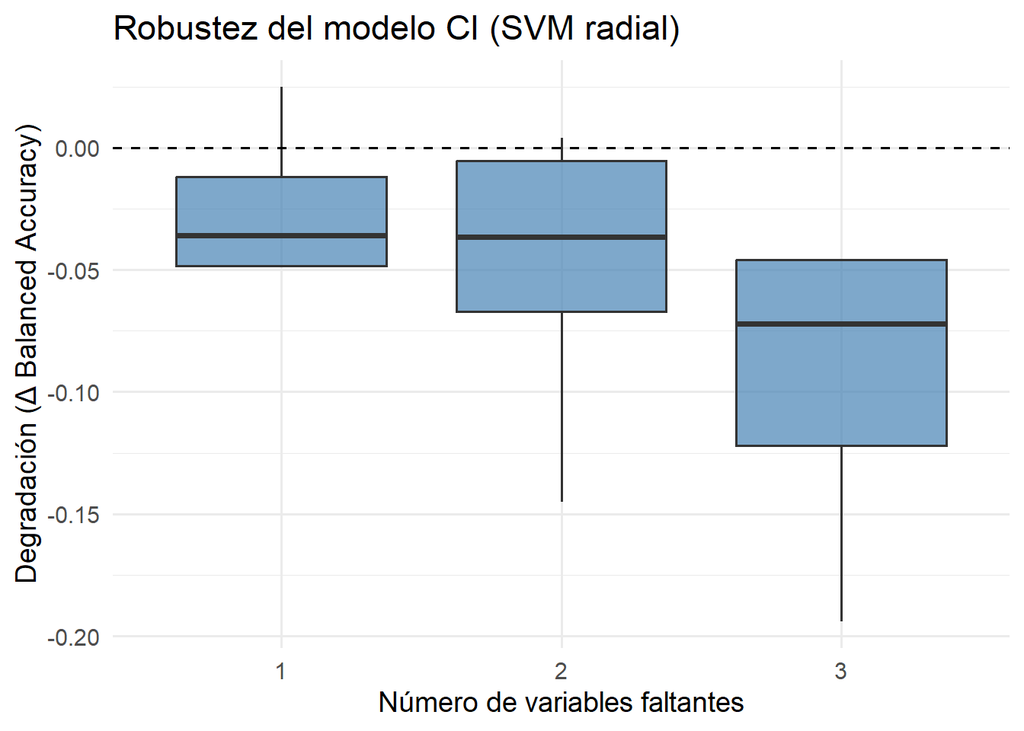

```r
#grafico en funcion variables faltantes CI
ggplot(robustez_CI_tabla,
       aes(x = factor(n_na),
           y = dBA)) +
  geom_boxplot(fill = "steelblue", alpha = 0.7) +
  geom_hline(yintercept = 0, linetype = "dashed") +
  theme_minimal(base_size = 14) +
  labs(
    x = "Número de variables faltantes",
    y = "Degradación (Δ Balanced Accuracy)",
    title = "Robustez del modelo CI (SVM radial)"
  )
```

```r
#reglas de confianza modelo CI
rules_confianza_CI <- robustez_CI_tabla %>%
  dplyr::mutate(
    nivel_confianza = dplyr::case_when(
      BA >= 0.75 ~ "Alta",
      BA >= 0.70 ~ "Moderada",
      TRUE       ~ "Baja"
    )
  ) %>%
  dplyr::arrange(n_na, BA)

rules_confianza_CI
```

| modelo | escenario | n_na | BA | dBA | nivel_confianza |
| --- | --- | --- | --- | --- | --- |
| CI_SVM | BLCu | 1 | 0.780 | -0.049 | Alta |
| CI_SVM | MDCu | 1 | 0.781 | -0.048 | Alta |
| CI_SVM | MD | 1 | 0.805 | -0.024 | Alta |
| CI_SVM | BL | 1 | 0.854 | 0.025 | Alta |
| CI_SVM | MD_MDCu | 2 | 0.683 | -0.145 | Baja |
| CI_SVM | MDCu_BLCu | 2 | 0.756 | -0.073 | Alta |
| CI_SVM | MD_BLCu | 2 | 0.780 | -0.049 | Alta |
| CI_SVM | BL_MDCu | 2 | 0.805 | -0.024 | Alta |
| CI_SVM | MD_BL | 2 | 0.830 | 0.001 | Alta |
| CI_SVM | BL_BLCu | 2 | 0.832 | 0.004 | Alta |

[output cut: 4 more lines]

```r
##grafico combinado
#union modelos
robustez_total <- dplyr::bind_rows(robustez_CS_tabla,
                                   robustez_CI_tabla)
#check
table(robustez_total$modelo)
```

```
##
## CI_SVM CS_XGB
##     14     14
```

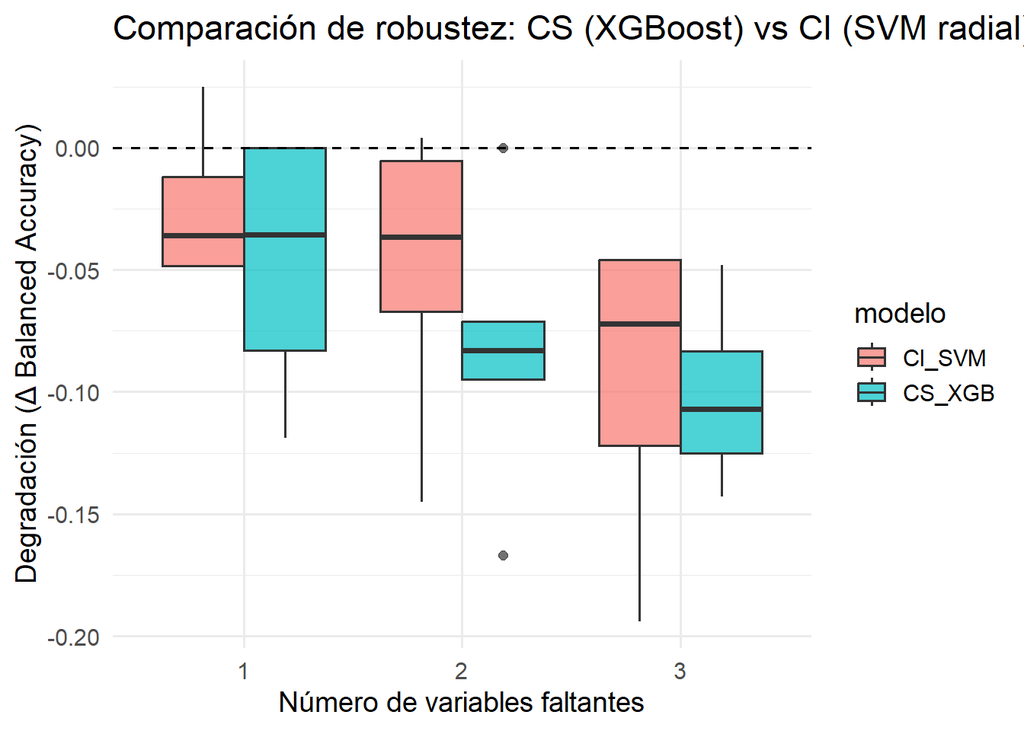

```r
ggplot(robustez_total,
       aes(x = factor(n_na),
           y = dBA,
           fill = modelo)) +
  geom_boxplot(alpha = 0.7,
               position = position_dodge(width = 0.75)) +
  geom_hline(yintercept = 0, linetype = "dashed") +
  theme_minimal(base_size = 14) +
  labs(
    x = "Número de variables faltantes",
    y = "Degradación (Δ Balanced Accuracy)",
    title = "Comparación de robustez: CS (XGBoost) vs CI (SVM radial)"
  )
```

```r
##Test pareado para perdida de BA entre modelos

#compilacion datos
robustez_pareado <- robustez_total %>%
  select(modelo, escenario, dBA) %>%
  tidyr::pivot_wider(
    names_from = modelo,
    values_from = dBA
  )
#check
head(robustez_pareado)
```

| escenario | CS_XGB | CI_SVM |
| --- | --- | --- |
| BL_BLCu | -0.167 | 0.004 |
| MD_BL_BLCu | -0.143 | -0.046 |
| MD_MDCu_BLCu | -0.119 | -0.194 |
| MDCu | -0.119 | -0.048 |
| MD_MDCu | -0.095 | -0.145 |
| MD_BLCu | -0.095 | -0.049 |

```r
#Wilcox para pareados
wilcox.test(
  robustez_pareado$CS_XGB,
  robustez_pareado$CI_SVM,
  paired = TRUE
)
```

```
##
##  Wilcoxon signed rank exact test
##
## data:  robustez_pareado$CS_XGB and robustez_pareado$CI_SVM
## V = 37, p-value = 0.3575
## alternative hypothesis: true location shift is not equal to 0
```

> Resultado congruente con valores observados mean_dBA CS ≈ -0.077 mean_dBA CI ≈ -0.056 La diferencia promedio es pequeña (~2%).